# R Notebook

```r
library(tidyverse)
library(broom)
```

## Question 1.A)

Here we read in the data using read csv and obtain a before and after for both male and female.

```r
my_url <- "http://ritsokiguess.site/STAC32/pulsemarch.csv"
pulsemarch = read_csv(my_url)
pulsemarch
```

| Sex | Before | After |
| --- | --- | --- |
| Female | 72 | 84 |
| Male | 60 | 72 |
| Female | 68 | 80 |
| Male | 70 | 72 |
| Male | 68 | 80 |
| Male | 61 | 75 |
| Male | 80 | 84 |
| Male | 72 | 76 |
| Female | 64 | 80 |
| Female | 62 | 92 |

[output cut: 30 more lines]

## Question 1.B

Our data involves two quantitative variables and one categorical variables therefore we use a scatterplot. Sex is represented according to two colours which are red for females and blue for males. We set our figure height to 6 so it is more convenient to notice the data trends

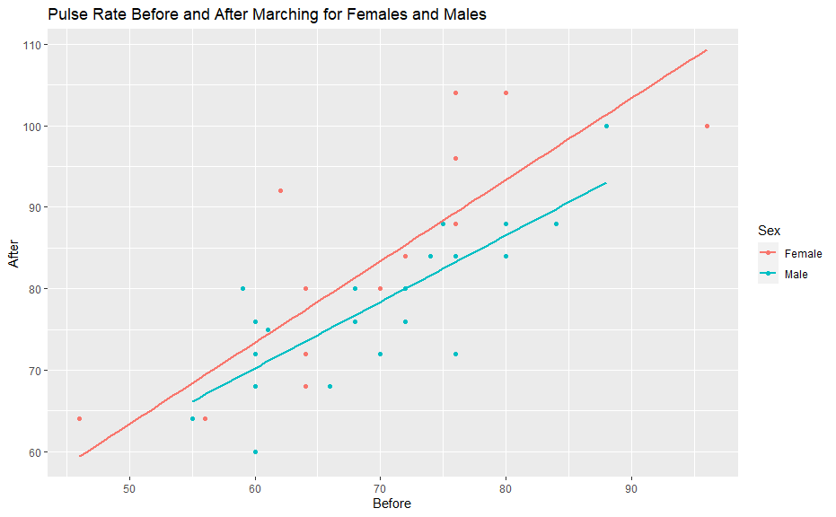

```r
ggplot(pulsemarch,aes(x= Before, y = After, colour = Sex)) +
  geom_point() + geom_smooth(method = "lm", se = FALSE) +
  labs(title = "Pulse Rate Before and After Marching for Females and Males")
```

## Question 1.C

Our data displays that whenever pulse rate is low before that it will be low as well after marching. We can see this as the regression line has a slope that goes upward. Effects on sex show that usually males will have a lower pulse rate before and after than females according to the data we have

## Question 1.D

Using the pulserate data of before and after, we run a regression predicting the pulserate after

```r
regpulserate <- lm(After ~ Before + Sex, data = pulsemarch)
summary(regpulserate)
```

```
Call:
lm(formula = After ~ Before + Sex, data = pulsemarch)

Residuals:
     Min       1Q   Median       3Q      Max
-11.8653  -4.6319  -0.4271   3.3856  16.0047

Coefficients:
            Estimate Std. Error t value Pr(>|t|)
(Intercept)  19.8003     7.9217   2.499   0.0170 *
Before        0.9064     0.1127   8.046  1.2e-09 ***
SexMale      -4.8191     2.2358  -2.155   0.0377 *
---
Signif. codes:  0 ‘***’ 0.001 ‘**’ 0.01 ‘*’ 0.05 ‘.’ 0.1 ‘ ’ 1

Residual standard error: 6.918 on 37 degrees of freedom
Multiple R-squared:  0.6468,    Adjusted R-squared:  0.6277
F-statistic: 33.87 on 2 and 37 DF,  p-value: 4.355e-09
```

We notice that the p values are less than 0.05 with a R-squared of about 0.65. SexMale has an estimate of about - 4.82.

## Question 1.E

As mentioned off the regression data the p values are less than 0.05 which indicates a significance for the variables in our data. The regression line told us before that the pulse rate for before and after marching will not be the same and males will be slightly lower therefore I am not surprised at all.

## Question 1.F

The numerical value of the estimate for sex in our regression output mean told us it is about -4.82 which means on average males will have a lower pulse rate before and after marching than females by about 4.82. Again from the graph and the regression data we obtained earlier this is not surprising as we expected this to occur. I hypothesize males have a lower pulse rate before and after marching than females possibly to due males exercising and playing sports more often than females. Frequent exercise will lower your pulse rate and heart rate.

## Question 2.A

We write a function named cv which allows us to calculate the coefficient of variation of its input and returns the result. Our function returns standard deviation divided by the mean of the input.

```r
cv <- function(x) {
  ans <- sd(x)/ mean(x)
  return(ans)
}
```

## Question 2.B

We use our cv function created to allow us to find the coefficient of variation of the set of integers of 1 through 5. We define “set” as the set of integers that are from 1 through 5 and we run our function on “set”.

```r
set <- c(1,2,3,4,5)
cv(set)
```

```
[1] 0.5270463
```

We obtain about 0.53 as our coefficient of variation.

## Question 2.C

We define “v” as a vector that contains, -2.8, -1.8, -0.8, 1.2 and 4.2 and run our cv function on it.

```r
v <- c(-2.8, -1.8, -0.8, 1.2, 4.2)
cv(v)
```

```
[1] 6.248491e+16
```

## Question 2.D

We should rewrite our function to avoid this error and producing a number that is this large. We will rewrite it so it produces an error if there are any negative numbers in the input.

```r
cv_no_neg <- function(x) {
  stopifnot(x >= 0)
  ans <- sd(x) / mean(x)
  return(ans)

}
```

```r
cv_no_neg(v)
```

```
Error in cv_no_neg(v) : x >= 0 are not all TRUE
```

As expected due to the three negative integers existing in the vector, we are returned with an error.